# Tugas-pertemuan-4

Rafi Adabhi Sunarya

# White Noise

Pembangkitan data berpola AR, MA, ARMA, dan banyak proses deret waktu lainnya diawali pembangkitan *white noise*. *White noise* merupakan sederet nilai dari peubah bebas stokastik identik. Oleh karena itu, *white noise* memiliki dua karakteristik penting:

1. *White noise* tidak memiliki autokorelasi (**karena saling bebas**)
2. Nilai harapan dan ragam *white noise* sama (**karena berasal dari peubah acak bebas stokastik identik**)

*White noise* dibangkitkan dari suatu peubah acak, umumnya peubah acak normal.

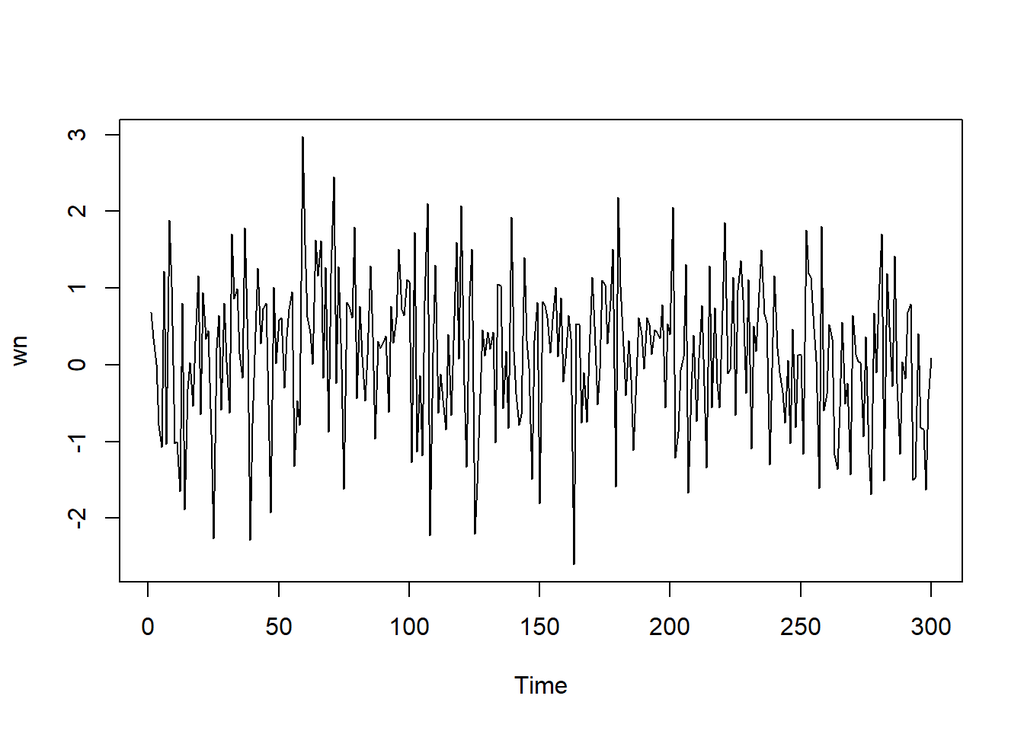

```r
set.seed(1106)  # set seed agar hasil random sama
wn <- rnorm(300)  # buat data white noise sebanyak 300
ts.plot(wn)  # tampilkan plot runtun waktu white noise
```

Dapat terlihat bahwa *white noise* tidak memiliki autokorelasi dari ACF. Perhatikan bahwa lag ke-0 adalah korelasi observasi ke-t dengan dirinya sendiri. Nilai korelasi tersebut pasti 1. Sebagai alternatif, lag pertama di plot ACF dapat ditetapkan sebagai 1 (alih-alih 0) dengan menambahkan argumen `xlim(1, lag akhir)`. Plot tersebut dapat disandingkan bersamaan dengan membuat matriks $1 \times 2$ dengan `par(mfrow = c(1,2))`.

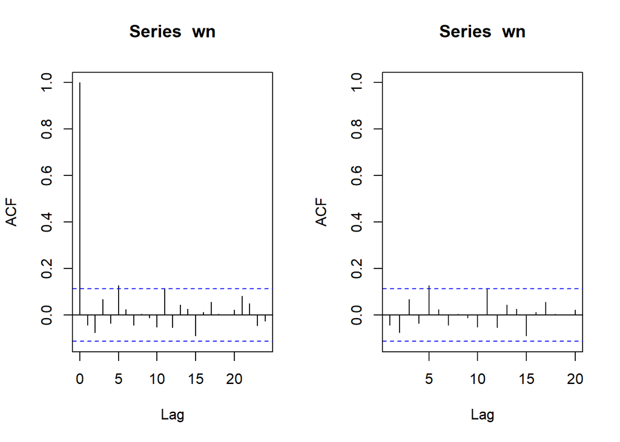

```r
par(mfrow = c(1, 2))  # bagi plot jadi 1 baris 2 kolom
acf(wn)  # plot ACF untuk white noise
acf(wn, xlim = c(1, 20))  # plot ACF white noise dibatasi sampai lag 20
```

# Proses MA

Proses MA dapat dituliskan sebagai berikut:

$$y_{t} = c + e_t + \theta_{1}e_{t-1} + \theta_{2}e_{t-2} + \dots +
\theta_{q}e_{t-q} = c+{e_t+\sum_{i=1}^p \theta_ie_{t-i}}$$

Terlihat bahwa $e_t$, atau *white noise*, berperan penting dalam pembangkitan proses MA.

## Pembangkitan Proses MA(2)

```r
set.seed(1106)  # set seed agar hasil sama setiap dijalankan
ma <- wn[1:2]  # ambil 2 nilai awal white noise sebagai starting value untuk MA
```

```r
for(i in 3:300){ # loop dari data ke-3 sampai ke-300
   ma[i] <- wn[i] + 0.4 * wn[i - 1] + 0.6 * wn[i - 2] # rumus MA(2) dengan θ1=0.4, θ2=0.6
}
ma
```

```
##   [1]  0.681435176  0.343900349  0.559725304 -0.572914422 -1.381876079
##   [6]  0.318833601 -1.190578531  2.205508475  1.158869635  0.515529330
##  [11] -0.802954686 -2.663943633 -0.461735804 -2.555661998 -0.595660189
##  [16] -1.229879439 -0.717037230  0.114727464  0.966383385  0.001447475
##  [21]  1.375255746  0.320949286  1.145815975 -0.526415413 -2.360354768
##  [26] -1.236053036 -0.630738773 -0.196313793  0.959108762  0.007980830
##  [31] -0.130835019  1.475729649  1.168353408  2.364175062  1.066481391
##  [36]  0.488228366  1.804437921  0.821864185 -1.131788699 -1.551148129
##  [41] -1.249390438  0.968172856  1.035750439  1.601487608  1.265296019
##  [46]  0.246657207 -1.655436243 -0.072481511 -0.737242632  1.197258563
##  [51]  0.859447834  0.302680059  0.615963729  0.696709921  1.463738348
##  [56] -0.503381539 -0.421627926 -1.767749143  2.377381523  2.287233487
##  [61]  3.034672486  1.608750074  0.546164556  1.883050035  1.815235176
##  [66]  3.057033800  1.166697702  2.167605012 -0.468528458  1.600390496
##  [71]  2.401261113  1.447780444  2.648001110  0.311157298 -0.872771737
```

[output cut: 45 more lines]

Selain menggunakan cara di atas, pembangkitan proses MA(2) dapat dilakukan dengan fungsi `arima.sim()` sebagai berikut.

```r
set.seed(1106) # supaya hasil simulasi bisa direplikasi
ma2 <- arima.sim(list(order=c(0,0,2), ma=c(0.4, 0.6)), n=300) # simulasi data MA(2) dengan theta1=0.4, theta2=0.6, panjang 300
ma2
```

```
## Time Series:
## Start = 1
## End = 300
## Frequency = 1
##   [1]  0.559725304 -0.572914422 -1.381876079  0.318833601 -1.190578531
##   [6]  2.205508475  1.158869635  0.515529330 -0.802954686 -2.663943633
##  [11] -0.461735804 -2.555661998 -0.595660189 -1.229879439 -0.717037230
##  [16]  0.114727464  0.966383385  0.001447475  1.375255746  0.320949286
##  [21]  1.145815975 -0.526415413 -2.360354768 -1.236053036 -0.630738773
##  [26] -0.196313793  0.959108762  0.007980830 -0.130835019  1.475729649
##  [31]  1.168353408  2.364175062  1.066481391  0.488228366  1.804437921
##  [36]  0.821864185 -1.131788699 -1.551148129 -1.249390438  0.968172856
##  [41]  1.035750439  1.601487608  1.265296019  0.246657207 -1.655436243
##  [46] -0.072481511 -0.737242632  1.197258563  0.859447834  0.302680059
##  [51]  0.615963729  0.696709921  1.463738348 -0.503381539 -0.421627926
```

[output cut: 49 more lines]

## Karakteristik MA(2)

### Plot Time Series

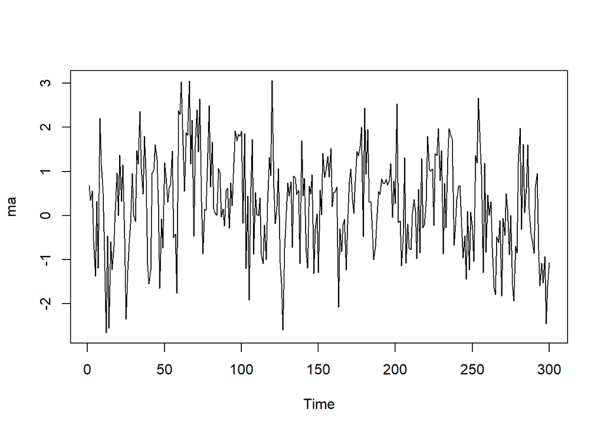

```r
ts.plot(ma) # membuat plot deret waktu (time series plot) dari objek 'ma'
```

Berdasarkan plot time series, terlihat bahwa data MA(2) yang dibangkitkan stasioner dalam rataan

### Plot ACF

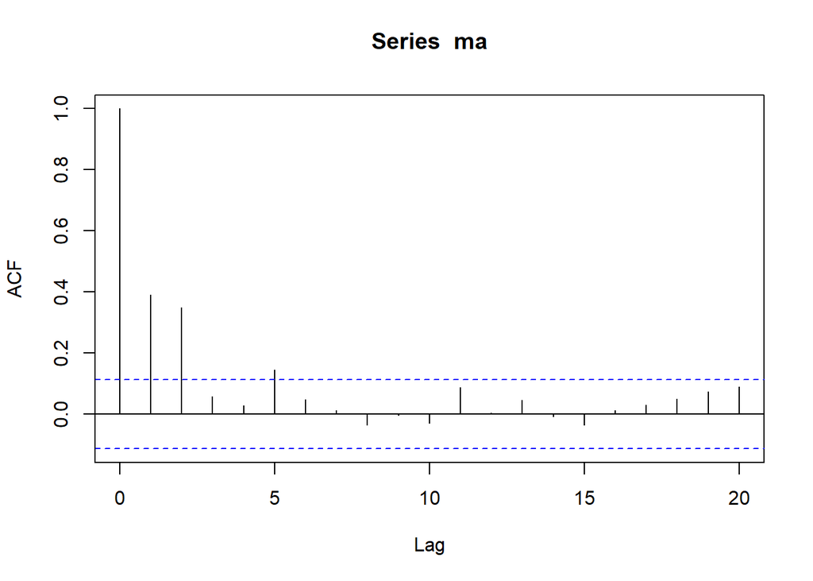

```r
acf(ma,lag.max = 20) # menampilkan plot autokorelasi (ACF) hingga lag ke-20 untuk data ma
```

Berdasarkan plot ACF tersebut, terlihat bahwa plot ACF *cuts off* di lag kedua

### Plot PACF

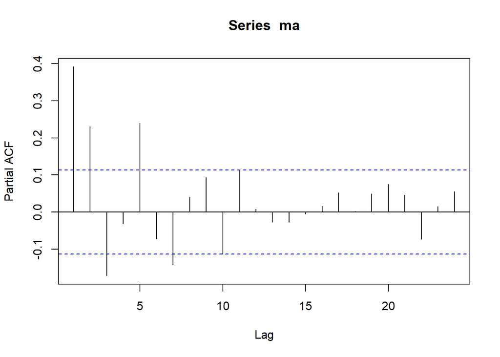

```r
pacf(ma)  # menampilkan plot Partial Autocorrelation Function (PACF) dari data ma
```

Berdasarkan plot PACF tersebut, terlihat bahwa plot PACF cenderung *tails off* dan membentuk gelombang sinus

### Plot EACF

```r
TSA::eacf(ma)
```

```
## AR/MA
##   0 1 2 3 4 5 6 7 8 9 10 11 12 13
## 0 x x o o x o o o o o o  o  o  o
## 1 x x x o x o o o o o o  o  o  o
## 2 x x o x x o o o o o o  o  o  o
## 3 x x x x x o o o o o o  o  o  o
## 4 x x x x x o o o o o o  o  o  o
## 5 x x x o x o o o o o o  o  o  o
## 6 x x o o o o o x o o o  o  o  o
## 7 x x o x o x o x o o o  o  o  o
```

Berdasarkan pola segitiga nol pada plot EACF, terlihat bahwa segitiga nol berada pada ordo AR(0) dan ordo MA(2)

### Scatterplot Antar Lag

#### Korelasi antara $Y_t$ dengan $Y_{t-1}$

```r
#Yt (mulai dari data ke-2 sampai ke-300)
yt_ma1 <- ma[-1]
yt_ma1
```

```
##   [1]  0.343900349  0.559725304 -0.572914422 -1.381876079  0.318833601
##   [6] -1.190578531  2.205508475  1.158869635  0.515529330 -0.802954686
##  [11] -2.663943633 -0.461735804 -2.555661998 -0.595660189 -1.229879439
##  [16] -0.717037230  0.114727464  0.966383385  0.001447475  1.375255746
##  [21]  0.320949286  1.145815975 -0.526415413 -2.360354768 -1.236053036
##  [26] -0.630738773 -0.196313793  0.959108762  0.007980830 -0.130835019
##  [31]  1.475729649  1.168353408  2.364175062  1.066481391  0.488228366
##  [36]  1.804437921  0.821864185 -1.131788699 -1.551148129 -1.249390438
##  [41]  0.968172856  1.035750439  1.601487608  1.265296019  0.246657207
##  [46] -1.655436243 -0.072481511 -0.737242632  1.197258563  0.859447834
##  [51]  0.302680059  0.615963729  0.696709921  1.463738348 -0.503381539
##  [56] -0.421627926 -1.767749143  2.377381523  2.287233487  3.034672486
##  [61]  1.608750074  0.546164556  1.883050035  1.815235176  3.057033800
##  [66]  1.166697702  2.167605012 -0.468528458  1.600390496  2.401261113
##  [71]  1.447780444  2.648001110  0.311157298 -0.872771737  0.138849274
```

[output cut: 45 more lines]

```r
# Yt-1 (mulai dari data ke-1 sampai ke-299)
yt_1_ma <- ma[-300]
yt_1_ma
```

```
##   [1]  0.681435176  0.343900349  0.559725304 -0.572914422 -1.381876079
##   [6]  0.318833601 -1.190578531  2.205508475  1.158869635  0.515529330
##  [11] -0.802954686 -2.663943633 -0.461735804 -2.555661998 -0.595660189
##  [16] -1.229879439 -0.717037230  0.114727464  0.966383385  0.001447475
##  [21]  1.375255746  0.320949286  1.145815975 -0.526415413 -2.360354768
##  [26] -1.236053036 -0.630738773 -0.196313793  0.959108762  0.007980830
##  [31] -0.130835019  1.475729649  1.168353408  2.364175062  1.066481391
##  [36]  0.488228366  1.804437921  0.821864185 -1.131788699 -1.551148129
##  [41] -1.249390438  0.968172856  1.035750439  1.601487608  1.265296019
##  [46]  0.246657207 -1.655436243 -0.072481511 -0.737242632  1.197258563
##  [51]  0.859447834  0.302680059  0.615963729  0.696709921  1.463738348
##  [56] -0.503381539 -0.421627926 -1.767749143  2.377381523  2.287233487
##  [61]  3.034672486  1.608750074  0.546164556  1.883050035  1.815235176
##  [66]  3.057033800  1.166697702  2.167605012 -0.468528458  1.600390496
##  [71]  2.401261113  1.447780444  2.648001110  0.311157298 -0.872771737
```

[output cut: 45 more lines]

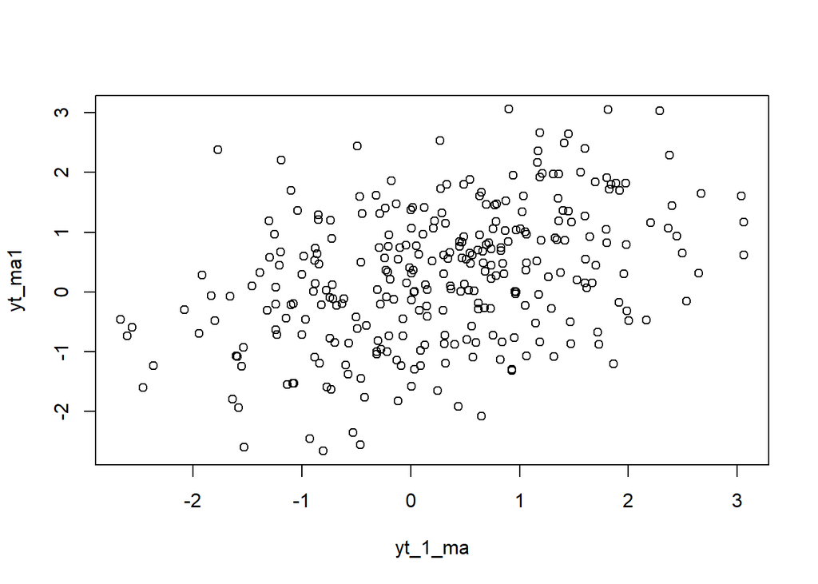

```r
plot(y=yt_ma1,x=yt_1_ma)
```

```r
cor(yt_ma1,yt_1_ma)
```

```
## [1] 0.3925083
```

#### Korelasi antara $Y_t$ dengan $Y_{t-2}$

```r
# Yt (mulai dari observasi ke-3 s/d 300)
yt_ma2 <- ma[-c(1,2)]
yt_ma2
```

```
##   [1]  0.559725304 -0.572914422 -1.381876079  0.318833601 -1.190578531
##   [6]  2.205508475  1.158869635  0.515529330 -0.802954686 -2.663943633
##  [11] -0.461735804 -2.555661998 -0.595660189 -1.229879439 -0.717037230
##  [16]  0.114727464  0.966383385  0.001447475  1.375255746  0.320949286
##  [21]  1.145815975 -0.526415413 -2.360354768 -1.236053036 -0.630738773
##  [26] -0.196313793  0.959108762  0.007980830 -0.130835019  1.475729649
##  [31]  1.168353408  2.364175062  1.066481391  0.488228366  1.804437921
##  [36]  0.821864185 -1.131788699 -1.551148129 -1.249390438  0.968172856
##  [41]  1.035750439  1.601487608  1.265296019  0.246657207 -1.655436243
##  [46] -0.072481511 -0.737242632  1.197258563  0.859447834  0.302680059
##  [51]  0.615963729  0.696709921  1.463738348 -0.503381539 -0.421627926
##  [56] -1.767749143  2.377381523  2.287233487  3.034672486  1.608750074
##  [61]  0.546164556  1.883050035  1.815235176  3.057033800  1.166697702
##  [66]  2.167605012 -0.468528458  1.600390496  2.401261113  1.447780444
##  [71]  2.648001110  0.311157298 -0.872771737  0.138849274  0.123654781
```

[output cut: 45 more lines]

```r
# Yt-2 (mulai dari observasi ke-1 s/d 298)
yt_2_ma <- ma[-c(299,300)]
yt_2_ma
```

```
##   [1]  0.681435176  0.343900349  0.559725304 -0.572914422 -1.381876079
##   [6]  0.318833601 -1.190578531  2.205508475  1.158869635  0.515529330
##  [11] -0.802954686 -2.663943633 -0.461735804 -2.555661998 -0.595660189
##  [16] -1.229879439 -0.717037230  0.114727464  0.966383385  0.001447475
##  [21]  1.375255746  0.320949286  1.145815975 -0.526415413 -2.360354768
##  [26] -1.236053036 -0.630738773 -0.196313793  0.959108762  0.007980830
##  [31] -0.130835019  1.475729649  1.168353408  2.364175062  1.066481391
##  [36]  0.488228366  1.804437921  0.821864185 -1.131788699 -1.551148129
##  [41] -1.249390438  0.968172856  1.035750439  1.601487608  1.265296019
##  [46]  0.246657207 -1.655436243 -0.072481511 -0.737242632  1.197258563
##  [51]  0.859447834  0.302680059  0.615963729  0.696709921  1.463738348
##  [56] -0.503381539 -0.421627926 -1.767749143  2.377381523  2.287233487
##  [61]  3.034672486  1.608750074  0.546164556  1.883050035  1.815235176
##  [66]  3.057033800  1.166697702  2.167605012 -0.468528458  1.600390496
##  [71]  2.401261113  1.447780444  2.648001110  0.311157298 -0.872771737
```

[output cut: 45 more lines]

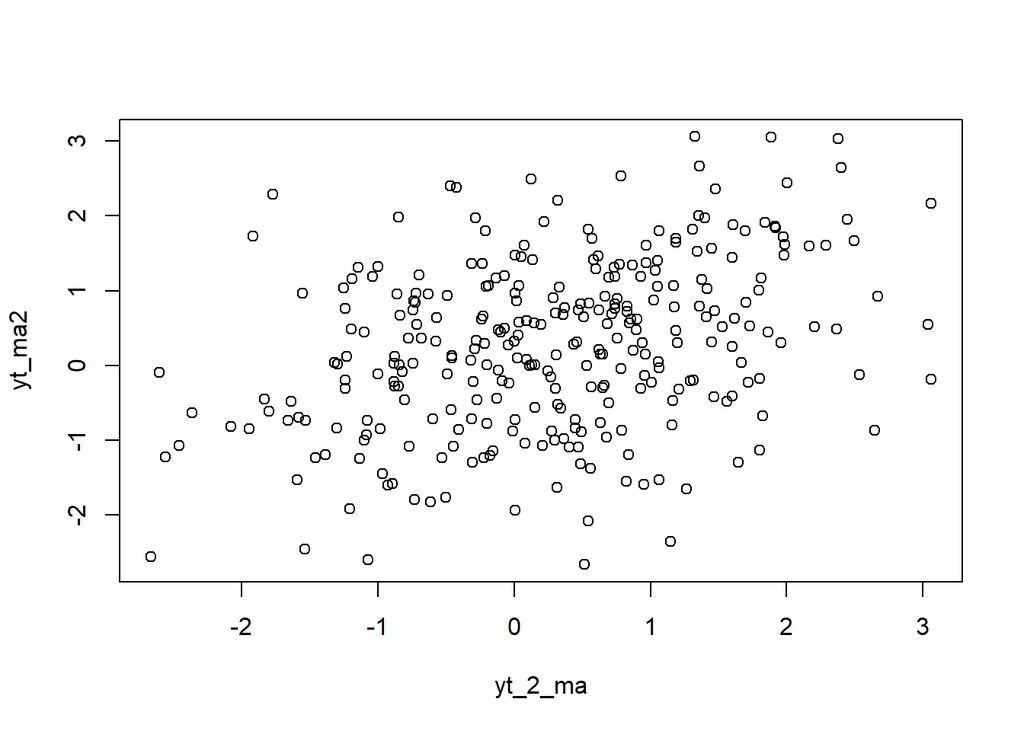

```r
plot(y=yt_ma2,x=yt_2_ma) # scatterplot Yt (sumbu Y) terhadap Yt-2 (sumbu X)
```

Berdasarkan scatterplot tersebut, terlihat bahwa terdapat hubungan positif antara $Y_t$ dengan $Y_{t-2}$. Hal ini sesuai dengan teori yang ada

```r
cor(yt_ma2,yt_2_ma) # menghitung korelasi antara Yt dan Yt-2
```

```
## [1] 0.3509585
```

Korelasi antara $Y_t$ dengan $Y_{t-2}$ dari hasil simulasi mendekati perhitungan teoritis yaitu

$$\rho_2 = \frac{\theta_2}{1 + \theta_1^2 + \theta_2^2} = \frac{0.6}{1 +
(0.4)^2 + (0.6)^2} = \frac{0.6}{1.52} \approx 0.3947$$

#### Korelasi antara $Y_t$ dengan $Y_{t-3}$

```r
# Yt (mulai dari data ke-4 sampai ke-300)
yt_ma3 <- ma[-c(1,2,3)]
yt_ma3
```

```
##   [1] -0.572914422 -1.381876079  0.318833601 -1.190578531  2.205508475
##   [6]  1.158869635  0.515529330 -0.802954686 -2.663943633 -0.461735804
##  [11] -2.555661998 -0.595660189 -1.229879439 -0.717037230  0.114727464
##  [16]  0.966383385  0.001447475  1.375255746  0.320949286  1.145815975
##  [21] -0.526415413 -2.360354768 -1.236053036 -0.630738773 -0.196313793
##  [26]  0.959108762  0.007980830 -0.130835019  1.475729649  1.168353408
##  [31]  2.364175062  1.066481391  0.488228366  1.804437921  0.821864185
##  [36] -1.131788699 -1.551148129 -1.249390438  0.968172856  1.035750439
##  [41]  1.601487608  1.265296019  0.246657207 -1.655436243 -0.072481511
##  [46] -0.737242632  1.197258563  0.859447834  0.302680059  0.615963729
##  [51]  0.696709921  1.463738348 -0.503381539 -0.421627926 -1.767749143
##  [56]  2.377381523  2.287233487  3.034672486  1.608750074  0.546164556
##  [61]  1.883050035  1.815235176  3.057033800  1.166697702  2.167605012
##  [66] -0.468528458  1.600390496  2.401261113  1.447780444  2.648001110
##  [71]  0.311157298 -0.872771737  0.138849274  0.123654781  1.408241258
```

[output cut: 45 more lines]

```r
# Yt-3 (mulai dari data ke-1 sampai ke-297)
yt_3_ma <- ma[-c(298,299,300)]
yt_3_ma
```

```
##   [1]  0.681435176  0.343900349  0.559725304 -0.572914422 -1.381876079
##   [6]  0.318833601 -1.190578531  2.205508475  1.158869635  0.515529330
##  [11] -0.802954686 -2.663943633 -0.461735804 -2.555661998 -0.595660189
##  [16] -1.229879439 -0.717037230  0.114727464  0.966383385  0.001447475
##  [21]  1.375255746  0.320949286  1.145815975 -0.526415413 -2.360354768
##  [26] -1.236053036 -0.630738773 -0.196313793  0.959108762  0.007980830
##  [31] -0.130835019  1.475729649  1.168353408  2.364175062  1.066481391
##  [36]  0.488228366  1.804437921  0.821864185 -1.131788699 -1.551148129
##  [41] -1.249390438  0.968172856  1.035750439  1.601487608  1.265296019
##  [46]  0.246657207 -1.655436243 -0.072481511 -0.737242632  1.197258563
##  [51]  0.859447834  0.302680059  0.615963729  0.696709921  1.463738348
##  [56] -0.503381539 -0.421627926 -1.767749143  2.377381523  2.287233487
##  [61]  3.034672486  1.608750074  0.546164556  1.883050035  1.815235176
##  [66]  3.057033800  1.166697702  2.167605012 -0.468528458  1.600390496
##  [71]  2.401261113  1.447780444  2.648001110  0.311157298 -0.872771737
```

[output cut: 45 more lines]

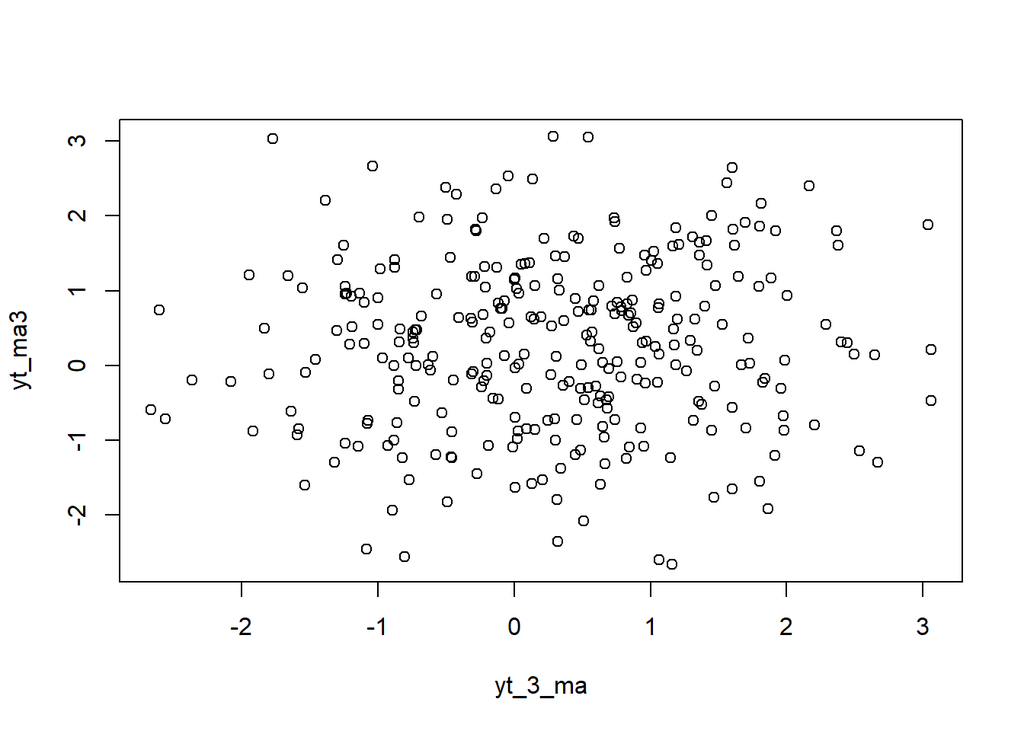

```r
plot(y=yt_ma3,x=yt_3_ma)
```

Berdasarkan scatterplot tersebut, terlihat bahwa cenderung tidak terdapat hubungan antara $Y_t$ dengan $Y_{t-3}$.

```r
cor(yt_ma3,yt_3_ma)
```

```
## [1] 0.05895331
```

Korelasi antara $Y_t$ dengan $Y_{t-3}$ hasil simulasi mendekati teori yang ada yaitu 0.

$$\rho_k = 0, \quad k > 2$$

# Proses AR

Proses AR dapat dituliskan sebagai berikut:

$$y_{t} = c + e_t + \phi_{1}Y_{t-1} +
\phi_{2}Y_{t-2} + \dots + \phi_{q}Y_{t-q} = c+{e_t+\sum_{i=1}^p
\phi_iY_{t-i}}$$
Terlihat bahwa $Y_t$ berperan penting dalam pembangkitan proses AR.

## Pembangkitan Proses AR

Akan dicoba membangkitkan proses AR paling sederhana, yaitu AR(2) dengan $\phi1 = 0.5$ dan $\phi1 = 0.2$ sebanyak 300 observasi dan $c=0$.

```r
set.seed(1106)
```

```r
n<-length(wn) # panjang data white noise
n
```

```
## [1] 300
```

```r
ar <- c(1:n) # inisialisasi vektor AR
ar[1:2] <- wn[1:2] # dua nilai awal = white noise

for(i in 3:n){
  ar[i] <- wn[i] + 0.5*ar[i-1] + 0.2*ar[i-2]  # AR(2)
}
ar
```

```
##   [1]  0.681435176  0.343900349  0.321541268 -0.555025551 -1.289232534
##   [6]  0.464369182 -1.058619863  1.450261223  1.537372115  0.032663050
##  [11] -0.683097922 -1.980553285 -0.326274935 -2.447836479 -1.609770849
##  [16] -1.262940097 -1.490707924 -0.687208609  0.522714370 -0.526861189
##  [21]  0.778002531  0.620288205  0.914762762 -0.326579159 -2.246895415
##  [26] -0.973382312 -0.293026470 -0.923949734  0.285806354 -0.006804524
##  [31] -0.574940818  1.417328918  1.456785507  2.007093776  1.445425758
##  [36]  0.955010149  2.548363680  1.675811564 -0.937525331 -0.897083559
##  [41] -0.208981691  0.971529161  0.721304901  1.292249196  1.594363237
##  [46]  0.538323053 -1.342865303  0.446495282 -0.028133695  0.659456088
##  [51]  0.939544553  0.307631926  0.706035281  1.141948725  1.666371643
##  [56] -0.259924882 -0.262229994 -0.971732094  2.433847454  2.594126267
##  [61]  2.406589826  2.138837985  1.556560066  2.836737731  2.889146150
##  [66]  3.626754252  2.216291443  3.102167371  1.123294144  2.369687695
##  [71]  3.858349627  2.158789727  3.127486779  1.942683412 -0.020658700
```

[output cut: 45 more lines]

Selain menggunakan cara di atas, pembangkitan proses AR dapat dilakukan dengan fungsi `arima.sim()` sebagai berikut.

```r
# AR(2) dengan phi1 = 0.5, phi2 = 0.2 dan n = 300
ar2_sim <- arima.sim(list(order = c(2,0,0), ar = c(0.5, 0.2)), n = 300)
ar2_sim
```

```
## Time Series:
## Start = 1
## End = 300
## Frequency = 1
##   [1] -0.973005933 -0.292739539 -0.923730992  0.285973111 -0.006677398
##   [6] -0.574843903  1.417402801  1.456841831  2.007136714  1.445458492
##  [11]  0.955035104  2.548382704  1.675826067 -0.937514275 -0.897075130
##  [16] -0.208975266  0.971534059  0.721308635  1.292252043  1.594365407
##  [21]  0.538324707 -1.342864041  0.446496244 -0.028132962  0.659456647
##  [26]  0.939544979  0.307632251  0.706035528  1.141948914  1.666371787
##  [31] -0.259924772 -0.262229911 -0.971732031  2.433847503  2.594126304
##  [36]  2.406589855  2.138838006  1.556560082  2.836737744  2.889146159
##  [41]  3.626754259  2.216291448  3.102167375  1.123294147  2.369687697
##  [46]  3.858349629  2.158789729  3.127486780  1.942683413 -0.020658699
##  [51]  1.195746465  1.360879278  1.530451597  2.828914284  1.286560449
```

[output cut: 49 more lines]

## Karakteristik AR(2)

### Plot Time Series

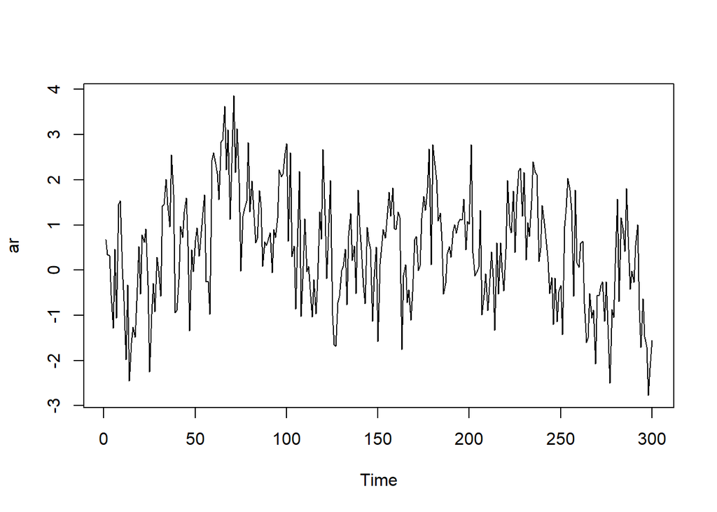

```r
ts.plot(ar)
```

Berdasarkan plot time series tersebut terlihat bahwa data cenderung stasioner pada rataan

### Plot ACF

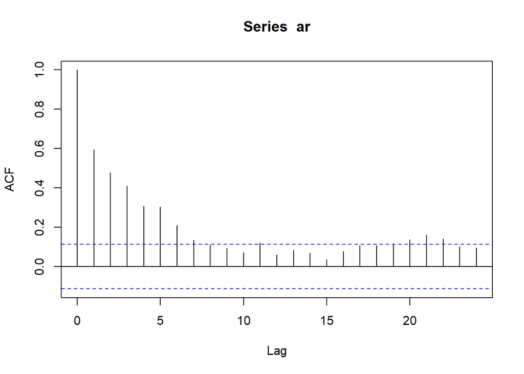

```r
acf(ar)
```

Berdasarkan plot ACF tersebut terlihat bahwa plot ACF cenderung *tails off*

### Plot PACF

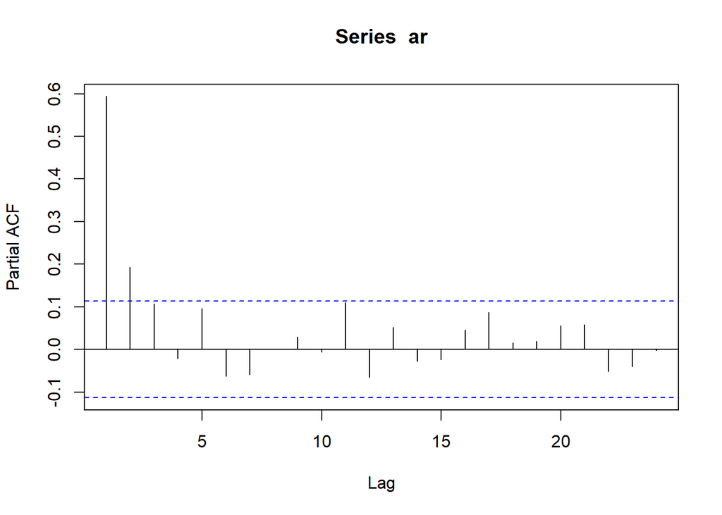

```r
pacf(ar)
```

### Plot EACF

```r
TSA::eacf(ar)
```

```
## AR/MA
##   0 1 2 3 4 5 6 7 8 9 10 11 12 13
## 0 x x x x x x x o o o x  o  o  o
## 1 x o o x x o o o o o x  o  o  o
## 2 x x o o x o o o o o o  o  o  o
## 3 x x o o x o o o o o o  o  o  o
## 4 x x o o x o o o o o o  o  o  o
## 5 x x x x o o o o o o o  o  o  o
## 6 x x o o o o o o o o o  o  o  o
## 7 o x o o o x o o o o o  o  o  o
```

Berdasarkan pola segitiga nol pada plot EACF, terlihat bahwa segitiga nol berada pada ordo AR(1) dan ordo MA(1)

### Scatterplot Antar Lag

#### Korelasi antara $Y_t$ dengan $Y_{t-1}$

```r
#Yt
yt_ar <- ar[-1]
yt_ar
```

```
##   [1]  0.343900349  0.321541268 -0.555025551 -1.289232534  0.464369182
##   [6] -1.058619863  1.450261223  1.537372115  0.032663050 -0.683097922
##  [11] -1.980553285 -0.326274935 -2.447836479 -1.609770849 -1.262940097
##  [16] -1.490707924 -0.687208609  0.522714370 -0.526861189  0.778002531
##  [21]  0.620288205  0.914762762 -0.326579159 -2.246895415 -0.973382312
##  [26] -0.293026470 -0.923949734  0.285806354 -0.006804524 -0.574940818
##  [31]  1.417328918  1.456785507  2.007093776  1.445425758  0.955010149
##  [36]  2.548363680  1.675811564 -0.937525331 -0.897083559 -0.208981691
##  [41]  0.971529161  0.721304901  1.292249196  1.594363237  0.538323053
##  [46] -1.342865303  0.446495282 -0.028133695  0.659456088  0.939544553
##  [51]  0.307631926  0.706035281  1.141948725  1.666371643 -0.259924882
##  [56] -0.262229994 -0.971732094  2.433847454  2.594126267  2.406589826
##  [61]  2.138837985  1.556560066  2.836737731  2.889146150  3.626754252
##  [66]  2.216291443  3.102167371  1.123294144  2.369687695  3.858349627
##  [71]  2.158789727  3.127486779  1.942683412 -0.020658700  1.195746464
```

[output cut: 45 more lines]

```r
#Yt-1
yt_1_ar <- ar[-300]
yt_1_ar
```

```
##   [1]  0.681435176  0.343900349  0.321541268 -0.555025551 -1.289232534
##   [6]  0.464369182 -1.058619863  1.450261223  1.537372115  0.032663050
##  [11] -0.683097922 -1.980553285 -0.326274935 -2.447836479 -1.609770849
##  [16] -1.262940097 -1.490707924 -0.687208609  0.522714370 -0.526861189
##  [21]  0.778002531  0.620288205  0.914762762 -0.326579159 -2.246895415
##  [26] -0.973382312 -0.293026470 -0.923949734  0.285806354 -0.006804524
##  [31] -0.574940818  1.417328918  1.456785507  2.007093776  1.445425758
##  [36]  0.955010149  2.548363680  1.675811564 -0.937525331 -0.897083559
##  [41] -0.208981691  0.971529161  0.721304901  1.292249196  1.594363237
##  [46]  0.538323053 -1.342865303  0.446495282 -0.028133695  0.659456088
##  [51]  0.939544553  0.307631926  0.706035281  1.141948725  1.666371643
##  [56] -0.259924882 -0.262229994 -0.971732094  2.433847454  2.594126267
##  [61]  2.406589826  2.138837985  1.556560066  2.836737731  2.889146150
##  [66]  3.626754252  2.216291443  3.102167371  1.123294144  2.369687695
##  [71]  3.858349627  2.158789727  3.127486779  1.942683412 -0.020658700
```

[output cut: 45 more lines]

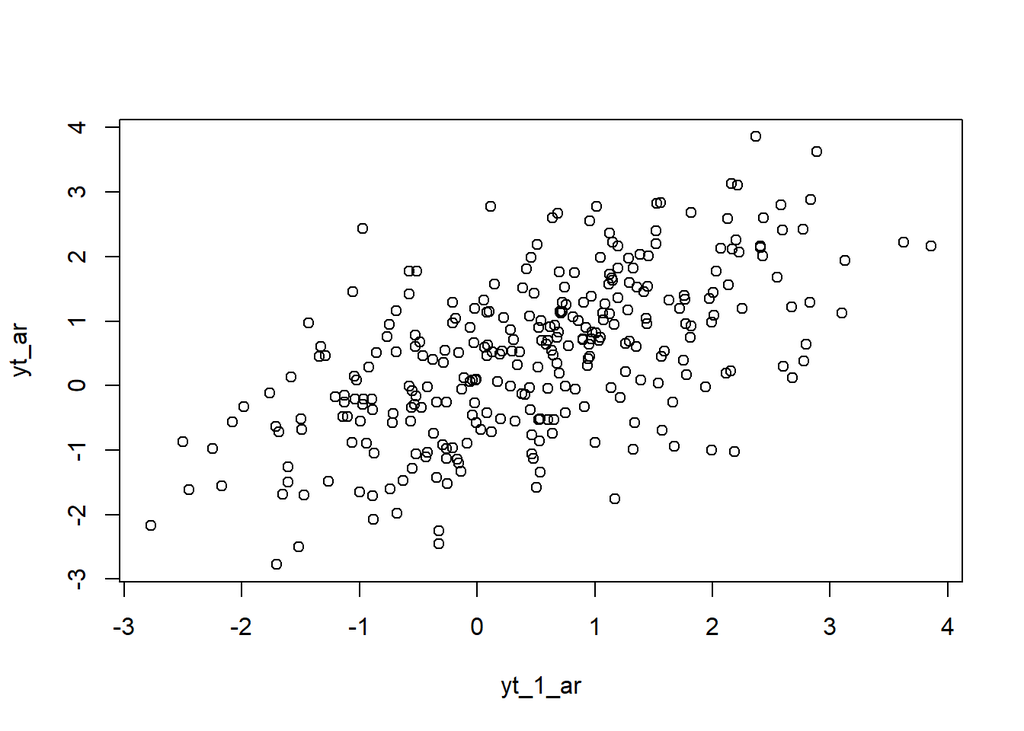

```r
plot(y=yt_ar,x=yt_1_ar)
```

Berdasarkan scatterplot tersebut, terlihat bahwa terdapat hubungan positif antara $Y_t$ dengan $Y_{t-1}$. Hal ini sesuai dengan teori yang ada

```r
cor(yt_ar,yt_1_ar)
```

```
## [1] 0.5966642
```

$$\rho_1 = \phi_1 + \phi_1 \phi_2 = 0.5 + (0.5)(0.2) = 0.6$$

#### Korelasi antara $Y_t$ dengan $Y_{t-2}$

```r
# Yt (mulai dari data ke-3 sampai ke-300)
yt_ar2 <- ar[-c(1,2)]
yt_ar2
```

```
##   [1]  0.321541268 -0.555025551 -1.289232534  0.464369182 -1.058619863
##   [6]  1.450261223  1.537372115  0.032663050 -0.683097922 -1.980553285
##  [11] -0.326274935 -2.447836479 -1.609770849 -1.262940097 -1.490707924
##  [16] -0.687208609  0.522714370 -0.526861189  0.778002531  0.620288205
##  [21]  0.914762762 -0.326579159 -2.246895415 -0.973382312 -0.293026470
##  [26] -0.923949734  0.285806354 -0.006804524 -0.574940818  1.417328918
##  [31]  1.456785507  2.007093776  1.445425758  0.955010149  2.548363680
##  [36]  1.675811564 -0.937525331 -0.897083559 -0.208981691  0.971529161
##  [41]  0.721304901  1.292249196  1.594363237  0.538323053 -1.342865303
##  [46]  0.446495282 -0.028133695  0.659456088  0.939544553  0.307631926
##  [51]  0.706035281  1.141948725  1.666371643 -0.259924882 -0.262229994
##  [56] -0.971732094  2.433847454  2.594126267  2.406589826  2.138837985
##  [61]  1.556560066  2.836737731  2.889146150  3.626754252  2.216291443
##  [66]  3.102167371  1.123294144  2.369687695  3.858349627  2.158789727
##  [71]  3.127486779  1.942683412 -0.020658700  1.195746464  1.360879278
```

[output cut: 45 more lines]

```r
# Yt-2 (mulai dari data ke-1 sampai ke-298)
yt_2_ar <- ar[-c(299,300)]
yt_2_ar
```

```
##   [1]  0.681435176  0.343900349  0.321541268 -0.555025551 -1.289232534
##   [6]  0.464369182 -1.058619863  1.450261223  1.537372115  0.032663050
##  [11] -0.683097922 -1.980553285 -0.326274935 -2.447836479 -1.609770849
##  [16] -1.262940097 -1.490707924 -0.687208609  0.522714370 -0.526861189
##  [21]  0.778002531  0.620288205  0.914762762 -0.326579159 -2.246895415
##  [26] -0.973382312 -0.293026470 -0.923949734  0.285806354 -0.006804524
##  [31] -0.574940818  1.417328918  1.456785507  2.007093776  1.445425758
##  [36]  0.955010149  2.548363680  1.675811564 -0.937525331 -0.897083559
##  [41] -0.208981691  0.971529161  0.721304901  1.292249196  1.594363237
##  [46]  0.538323053 -1.342865303  0.446495282 -0.028133695  0.659456088
##  [51]  0.939544553  0.307631926  0.706035281  1.141948725  1.666371643
##  [56] -0.259924882 -0.262229994 -0.971732094  2.433847454  2.594126267
##  [61]  2.406589826  2.138837985  1.556560066  2.836737731  2.889146150
##  [66]  3.626754252  2.216291443  3.102167371  1.123294144  2.369687695
##  [71]  3.858349627  2.158789727  3.127486779  1.942683412 -0.020658700
```

[output cut: 45 more lines]

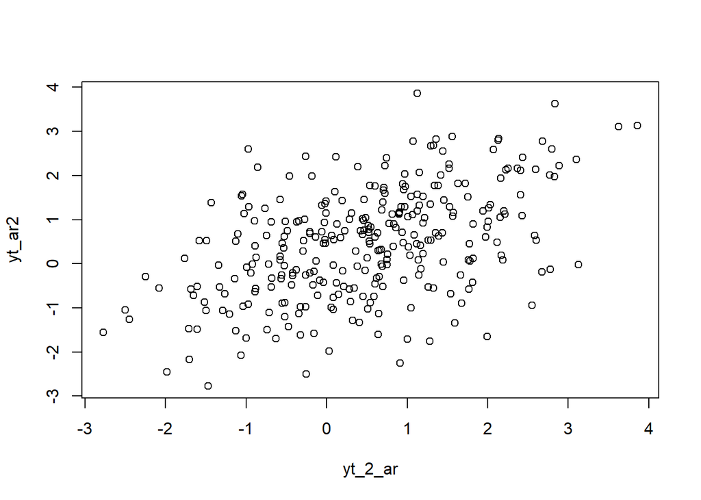

```r
plot(y=yt_ar2,x=yt_2_ar)
```

Berdasarkan scatterplot tersebut, terlihat bahwa terdapat hubungan positif antara $Y_t$ dengan $Y_{t-2}$. Hal ini sesuai dengan teori yang ada

```r
cor(yt_ar2,yt_2_ar)
```

```
## [1] 0.4835708
```

$$\rho_2 = \phi_1 \rho_1 + \phi_2 = 0.5 \cdot 0.6 + 0.2 = 0.5$$

#### Korelasi antara $Y_t$ dengan $Y_{t-3}$

```r
# Yt (mulai dari data ke-4 sampai ke-300)
yt_ar3 <- ar[-c(1,2,3)]
yt_ar3
```

```
##   [1] -0.555025551 -1.289232534  0.464369182 -1.058619863  1.450261223
##   [6]  1.537372115  0.032663050 -0.683097922 -1.980553285 -0.326274935
##  [11] -2.447836479 -1.609770849 -1.262940097 -1.490707924 -0.687208609
##  [16]  0.522714370 -0.526861189  0.778002531  0.620288205  0.914762762
##  [21] -0.326579159 -2.246895415 -0.973382312 -0.293026470 -0.923949734
##  [26]  0.285806354 -0.006804524 -0.574940818  1.417328918  1.456785507
##  [31]  2.007093776  1.445425758  0.955010149  2.548363680  1.675811564
##  [36] -0.937525331 -0.897083559 -0.208981691  0.971529161  0.721304901
##  [41]  1.292249196  1.594363237  0.538323053 -1.342865303  0.446495282
##  [46] -0.028133695  0.659456088  0.939544553  0.307631926  0.706035281
##  [51]  1.141948725  1.666371643 -0.259924882 -0.262229994 -0.971732094
##  [56]  2.433847454  2.594126267  2.406589826  2.138837985  1.556560066
##  [61]  2.836737731  2.889146150  3.626754252  2.216291443  3.102167371
##  [66]  1.123294144  2.369687695  3.858349627  2.158789727  3.127486779
##  [71]  1.942683412 -0.020658700  1.195746464  1.360879278  1.530451597
```

[output cut: 45 more lines]

```r
# Yt-3 (mulai dari data ke-1 sampai ke-297)
yt_3_ar <- ar[-c(298,299,300)]
yt_3_ar
```

```
##   [1]  0.681435176  0.343900349  0.321541268 -0.555025551 -1.289232534
##   [6]  0.464369182 -1.058619863  1.450261223  1.537372115  0.032663050
##  [11] -0.683097922 -1.980553285 -0.326274935 -2.447836479 -1.609770849
##  [16] -1.262940097 -1.490707924 -0.687208609  0.522714370 -0.526861189
##  [21]  0.778002531  0.620288205  0.914762762 -0.326579159 -2.246895415
##  [26] -0.973382312 -0.293026470 -0.923949734  0.285806354 -0.006804524
##  [31] -0.574940818  1.417328918  1.456785507  2.007093776  1.445425758
##  [36]  0.955010149  2.548363680  1.675811564 -0.937525331 -0.897083559
##  [41] -0.208981691  0.971529161  0.721304901  1.292249196  1.594363237
##  [46]  0.538323053 -1.342865303  0.446495282 -0.028133695  0.659456088
##  [51]  0.939544553  0.307631926  0.706035281  1.141948725  1.666371643
##  [56] -0.259924882 -0.262229994 -0.971732094  2.433847454  2.594126267
##  [61]  2.406589826  2.138837985  1.556560066  2.836737731  2.889146150
##  [66]  3.626754252  2.216291443  3.102167371  1.123294144  2.369687695
##  [71]  3.858349627  2.158789727  3.127486779  1.942683412 -0.020658700
```

[output cut: 45 more lines]

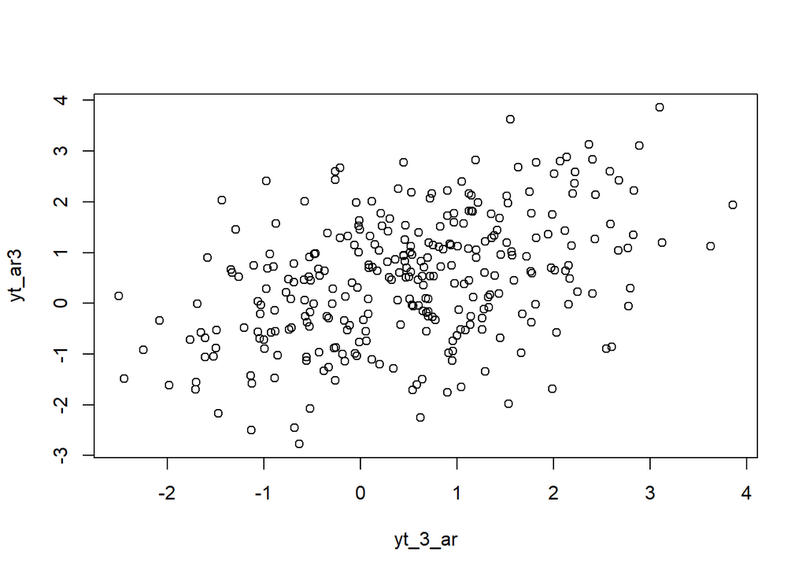

```r
plot(y=yt_ar3,x=yt_3_ar)
```

```r
cor(yt_ar3,yt_3_ar)
```

```
## [1] 0.420926
```